# Collaborative Data Activity - Categorical Outcomes

J Bhanji and V Lobue

11/22/2022

## General process to analyze categorical outcomes with categorical predictors

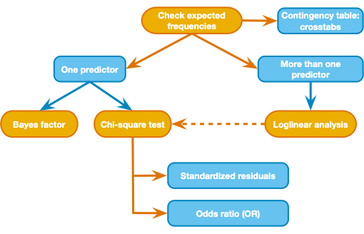

## Step 0 - Install a package

- This activity makes use of two new packages: “janitor” (for data cleaning), and “vcd” (for odds ratio calculation)

## Step 1 - Import the data

- we make use of the “janitor” package in this doc
- allow “na” and “n/a” as missing values
- create unique id for reach row
- here’s a link to the tsv file if you want to check it out on your own

```r
pub_tib <- readr::read_delim("data/Dataset-PublicationStatistics-2022.tsv",
                           na=c("n/a","na","N/A","NA","Na","N/a",""), delim = "\t",
                           show_col_types = FALSE) %>%
  janitor::clean_names() %>%  #fixes the column names
  janitor::remove_empty(which = "rows") %>%  # drop empty rows
  mutate(id = row_number(), .before = 1) %>%   #add a column with id for each row
  mutate(across(where(is.character), str_trim)) %>% #remove trailing/leading whitespace
  mutate(across(where(is.character), tolower)) %>% #make all text columns lowercase
  select(-student_name,-citation,-doi) #drop columns that we won't use here
```

## Step 2 - clean the data and set variable types

Check values of our variables:  
1. binary variables (reported yes/no): store as factor and check levels  
2. numerical (e.g., participants): convert “no” to NA and store as numerical  
3. field: since one entry can belong to multiple fields, we create a series of dummy coded variables `soc`,`cog`,`dev`, etc where a row gets a value of 1 if the given field appears in the `field` column. there is some variance in how fields are entered (“social”/“soc”, “cognitive”/“cog) so we’ll just check for a key part of text for each.  
4. sample_size_justification: store as factor and check levels

```r
#fix typos where "no" was entered as "on"
pub_tib <- pub_tib %>% mutate(
  income_or_ses_reported = str_replace(income_or_ses_reported, pattern = "on", replacement = "no")
)

#1. binary variables - using "factor" instead of "as_factor" because it will put
#   the levels in alpha order - NA values are recoded as "no"
pub_tib <- pub_tib %>% mutate(
  race_ethn_reported = factor(replace_na(race_ethn_reported,"no")),
  income_or_ses_reported = factor(replace_na(income_or_ses_reported,"no")),
  location_reported = factor(replace_na(location_reported,"no")),
  general_sample = factor(replace_na(general_sample,"no")),
  sample_size_justification = factor(sample_size_justification)
)
pub_tib %>% select(race_ethn_reported:general_sample,sample_size_justification) %>% purrr::map(levels)
```

```
## $race_ethn_reported
## [1] "no"  "yes"
##
## $income_or_ses_reported
## [1] "no"  "yes"
##
## $location_reported
## [1] "no"  "yes"
##
## $general_sample
## [1] "no"  "yes"
##
## $sample_size_justification
## [1] "a-priori"         "accuracy"         "constraints"      "heuristics"
## [5] "no-justification" "no-statement"     "population"
```

```r
pub_tib %>% count(race_ethn_reported)
```

```
## # A tibble: 2 × 2
##   race_ethn_reported     n
##   <fct>              <int>
## 1 no                   132
## 2 yes                   84
```

```r
pub_tib %>% count(income_or_ses_reported)
```

```
## # A tibble: 2 × 2
##   income_or_ses_reported     n
##   <fct>                  <int>
## 1 no                       162
## 2 yes                       54
```

```r
pub_tib %>% count(location_reported)
```

```
## # A tibble: 2 × 2
##   location_reported     n
##   <fct>             <int>
## 1 no                   68
## 2 yes                 148
```

```r
pub_tib %>% count(general_sample)
```

```
## # A tibble: 2 × 2
##   general_sample     n
##   <fct>          <int>
## 1 no                64
## 2 yes              152
```

```r
pub_tib %>% count(sample_size_justification)
```

```
## # A tibble: 8 × 2
##   sample_size_justification     n
##   <fct>                     <int>
## 1 a-priori                     17
## 2 accuracy                      4
## 3 constraints                   2
## 4 heuristics                    8
## 5 no-justification             14
## 6 no-statement                 62
## 7 population                    3
## 8 <NA>                        106
```

```r
#2. Numerical variables: participants_male and participants_female are stored as chr
#   use parse_number() and any non-numeric values will get NA
#   but there's an inconsistency in reporting NA/no versus 0 - we would need to
#   resolve the inconsistency to make use of that data
pub_tib <- pub_tib %>% mutate(
  participants_male = parse_number(participants_male, na = "no"),
  participants_female = parse_number(participants_female, na = "no"),
  participants_nonbin = parse_number(participants_nonbin, na = "no")
)
pub_tib %>% select(participants_n:participants_nonbin) %>% psych::describe()
```

```
##                     vars   n   mean      sd median trimmed    mad min   max
## participants_n         1 216 588.59 1761.62    125  218.49 140.11  12 18608
## participants_male      2 185 279.31  754.03     55  110.05  63.75   0  6714
## participants_female    3 188 311.56 1050.63     69  117.26  81.54   0 11894
## participants_nonbin    4  29   1.10    3.56      0    0.40   0.00   0    19
##                     range skew kurtosis     se
## participants_n      18596 6.57    54.08 119.86
## participants_male    6714 5.40    34.56  55.44
## participants_female 11894 8.12    79.16  76.62
## participants_nonbin    19 4.37    19.06   0.66
```

```r
#3. check out "field"
pub_tib %>% count(field)  #or use janitor::tabyl(field)
```

```
## # A tibble: 46 × 2
##    field                  n
##    <chr>              <int>
##  1 clinical, cog, dev     1
##  2 cog                   16
##  3 cog , other            1
##  4 cog, dev              14
##  5 cog, dev, soc          1
##  6 cog, neuro             2
##  7 cog, neuro, dev        7
##  8 cog, neuro, soc        1
##  9 cog, other             2
## 10 cog, soc               6
## # … with 36 more rows
## # ℹ Use `print(n = ...)` to see more rows
```

```r
# now dummy code the "field" variable, allowing for multiple fields per entry
pub_tib <- pub_tib %>%
  mutate(
    soc = if_else(str_detect(field,"soc"), 1, 0),
    cog = if_else(str_detect(field,"cog"), 1, 0),
    dev = if_else(str_detect(field,"dev"), 1, 0),
    pers = if_else(str_detect(field,"pers"), 1, 0),
    conbeh = if_else(str_detect(field,"con"), 1, 0),
    neuro = if_else(str_detect(field,"neuro"), 1, 0),
    quant = if_else(str_detect(field,"quant"), 1, 0),
    other = if_else(str_detect(field,"other"), 1, 0),
    #field_combo = ""
  )
# print counts of each field
pub_tib %>% select(soc:other) %>% colSums(na.rm = TRUE)
```

```
##    soc    cog    dev   pers conbeh  neuro  quant  other
##     73    125     57      6     14     70      0     15
```

```r
# no quant cases so drop that column
pub_tib <- pub_tib %>% select(-quant)
```